# OPI Forecasts 2026

Thomas Buehrens, WDFW (tbuehrens@dfw.wa.gov), Mark Sorel, WDFW (mark.sorel@dfw.wa.gov), Cassandra Leeman, ODFW (cassandra.r.leeman@odfw.oregon.gov), and Shannon Conley, WDFW (shannon.conley@dfw.wa.gov)

Last Updated 02/03/2026.

# Overview

This report details the process of fitting Auto-Regressive Integrated Moving Average (ARIMA) models to forecast OPI Coho salmon runsize. The model functions are flexibly configured to allow the user to supply total runsize data and a series of covariates.

```r
options(width = 100)
knitr::opts_chunk$set(message = FALSE)
set.seed(123)
```

```r
wd_functions<-"functions"
sapply(FUN = source, paste(wd_functions, list.files(wd_functions), sep="/"))
```

```r
packages_list<-c("tidyverse"
                 ,"forecast"
                 ,"mgcv"
                 ,"ggplot2"
                 ,"MASS"
                 ,"RColorBrewer"
                 ,"kableExtra"
                 ,"modelr"
                 ,"kableExtra"
                 ,"reshape2"
                 ,"ggfortify"
                 ,"clock"
                 ,"smooth"
                 ,"scales"
                 ,"gtools"
                 # ,"CombMSC"
                 ,"here"
                 ,"MuMIn"
                 ,"janitor"
                 ,"rvest"
                 ,"lubridate"
                 ,"rnoaa"
                 ,"ncdf4"
                 ,"magrittr"
                 ,"ggcorrplot"
                 ,"parallel"
                 ,"foreach"
                 ,"doParallel"
                 ,"readxl"
                 )
install_or_load_pack(packages = packages_list)

 if(!require(SalmonForecasting)|(packageVersion("SalmonForecasting")!="0.1.0")){
   devtools::install_github("wdfw-fp/salmonforecast@v0.1.0")
   }


# pacman::p_load(tidyverse
#                  ,forecast
#                  ,mgcv
#                  ,ggplot2
#                  ,MASS
#                  ,RColorBrewer
#                  ,kableExtra
#                  ,modelr
#                  ,kableExtra
#                  ,reshape2
#                  ,ggfortify
#                  ,clock
#                  ,smooth
#                  ,scales
#                  ,gtools
#                  ,CombMSC
#                  ,here
#                  ,MuMIn
#                  ,janitor
#                  ,rvest
#                  ,lubridate
#                  ,rnoaa
#                  ,ncdf4
#                  ,magrittr
#                  ,ggcorrplot
#                  ,parallel
#                  ,foreach
#                  ,doParallel
#                  ,readxl)
```

## User Inputs

This section contains parameters input to control the forecasting process

```r
#=========
# Raw Data
#=========
yr_start<-1967
yr_end<-year(Sys.Date())
#dam="BON"
species="Coho"
#===========================
# Summarization for analysis
#===========================
date_start_analysis<-ymd("1967/1/1") #this will be the first date of data used in the analysis (and this month/day first in years thereafter)
date_end_analysis<-ymd("2026/12/31") #this will be the last date of data used in the analysis (and this month/day last in years preceding)
forecast_period_start_m<-1 #this will be the month associated with the first month/day of the seasonal estimate period each year...can be after first data used to estimate it or the same
forecast_period_start_d<-1 #this will be the month day associated with the first month/day of the seasonal estimate period each year...can be after first data used to estimate it or the same
last_data<-Sys.Date()
#==================
#forecasting params
#==================
leave_yrs<- 31
TY_ensemble<-16
k<-1
                                                                                            covariates<-c(#new
                                                                                                          "lag1_log_JackOPI"
                                                                                                          ,"lag1_log_SmAdj"
                                                                                                          ,"lag1_NPGO"
                                                                                                          ,"lag1_PDO"
                                                                                                          ,"WSST_A"

                                                                                                          #OCN
                                                                                                          ,"PDO.MJJ"
                                                                                                          ,"MEI.OND"
                                                                                                          ,"UWI.JAS"
                                                                                                          ,"SST.AMJ"
                                                                                                          ,"SSH.AMJ"
                                                                                                          ,"UWI.SON"

                                                                                                          #Very correlated with variables already included
                                                                                                          #,"lag1_fall_Nino3.4"
                                                                                                          #,"SST.J"

                                                                                                          #Original OPIT indicators very correlated with variables already used(but untransformed)
                                                                                                          #"lag1_JackOPI"
                                                                                                          #,"lag1_SmAdj"

                                                                                                          #NOAA Ocean Indicators
                                                                                                          #,"lag1_sp_phys_trans"
                                                                                                          #,"lag1_PC1"
                                                                                                          )
plot_results = F
first_forecast_period = 1
write_model_summaries = TRUE
find_best=T
redo_forecasts=FALSE #where to do one-year-ahead forecasts for all models and years if there is a file saved with some. Change to TRUE if changing the min or max number of variables allowed per model, the covariates, or adding a new year of data. TO-DO: add functionality to only make projections for years or models that don't exist and get rid of any that you don't want (e.g., if you reduce max number of covariates per model)
#==============
#Ensemble Params
#===============
min_vars<-0
max_vars<-6
forecast_type<-"preseason"
stack_metric<-"MAPE"
num_models<-10
rolling_year_window<-15
alpha<-0.3 # exponential smoothing of APE calculations

inputs<-list(
  yr_start = yr_start,
  yr_end = yr_end,
  species = species,
  date_start_analysis = date_start_analysis,
  date_end_analysis = date_end_analysis,
  forecast_period_start_m = forecast_period_start_m,
  forecast_period_start_d = forecast_period_start_d,
  last_data = last_data,
  leave_yrs = leave_yrs,
  TY_ensemble = TY_ensemble,
  k = k,
  covariates = covariates,
  plot_results = plot_results,
  first_forecast_period = first_forecast_period,
  write_model_summaries = write_model_summaries,
  find_best = find_best,
  min_vars = min_vars,
  max_vars = max_vars,
  forecast_type = forecast_type,
  stack_metric = stack_metric,
  num_models = num_models,
  rolling_year_window=rolling_year_window,
  redo_forecasts=redo_forecasts,
  alpha=alpha
)

print(inputs)
```

```
## $yr_start
## [1] 1967
##
## $yr_end
## [1] 2026
##
## $species
## [1] "Coho"
##
## $date_start_analysis
## [1] "1967-01-01"
##
## $date_end_analysis
## [1] "2026-12-31"
##
## $forecast_period_start_m
## [1] 1
##
## $forecast_period_start_d
## [1] 1
##
## $last_data
## [1] "2026-02-03"
##
## $leave_yrs
## [1] 31
##
## $TY_ensemble
## [1] 16
##
## $k
## [1] 1
##
## $covariates
##  [1] "lag1_log_JackOPI" "lag1_log_SmAdj"   "lag1_NPGO"        "lag1_PDO"         "WSST_A"
##  [6] "PDO.MJJ"          "MEI.OND"          "UWI.JAS"          "SST.AMJ"          "SSH.AMJ"
## [11] "UWI.SON"
##
## $plot_results
## [1] FALSE
```

[output cut: 18 more lines]

```
##
## $stack_metric
## [1] "MAPE"
##
## $num_models
## [1] 10
##
## $rolling_year_window
## [1] 15
##
## $redo_forecasts
## [1] FALSE
##
## $alpha
## [1] 0.3
```

## Get Raw Data

Here we load the response variable (observed OPI coho abundance) and covariates used in past forecasts from Erik Suring’s GitHub repository [**OPIH Evaluation**](https://github.com/ErikSuring/OPIH_Evaluation). We also load covariates used in the Oregon Coast Natural (OCN) coho forecast, as well as ancillary additional covariates. More details are available in the appendix.

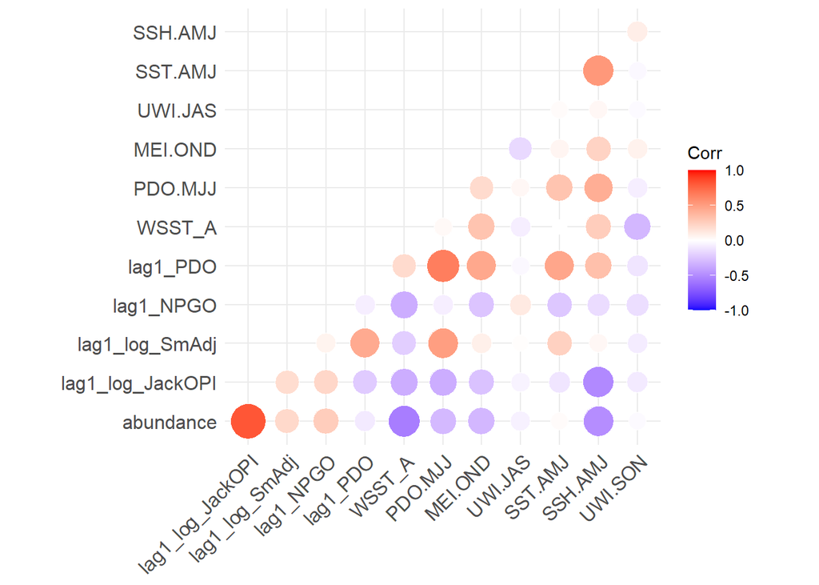

```r
make_dat<-function(file_path){

if(file.exists(file_path)){
  return(read_csv(here::here(file_path)))

}else{
#OPIHData <- read.table("https://raw.githubusercontent.com/ErikSuring/OPIH_Evaluation/main/PUB2023.txt", header = TRUE, sep = "\t", strip.white = TRUE, comment.char = "#")
# OPIHData<-read.table(here::here("data/PUB2024_manual_update.txt"), header = TRUE, sep = "\t", strip.white = TRUE, comment.char = "#")
OPIHData<-readxl::read_excel(here::here("data/covars_jan2025_MS.xlsx")) |> as.data.frame()

if(max(OPIHData$Year)<year(Sys.Date())){
  maxyear=max(OPIHData$Year)+1
  OPIHData%<>%
    right_join(tibble(Year=c(unique(OPIHData$Year),year(Sys.Date()))))
}

nYears <- length(OPIHData[,1])
earliestYear <- OPIHData[1,1]
latestYear <- OPIHData[nYears,1]

OPIHData$AdltAll <- c(OPIHData$AdltSRS[1:17],OPIHData$AdltMSM[18:nYears])   # row 18  <-  1986. Use SRS data prior, MSM data post
OPIHData$AdltAllno83 <- OPIHData$AdltAll
OPIHData$AdltAllno83[15] <-  NA   #  1983 is removed from model input data
OPIHData[,"AdltAll"] <- OPIHData$AdltAll
OPIHData[,"AdltAllno83"] <- OPIHData$AdltAllno83

# Lag Jack and Smolt data to return year
OPIHData[,"lagJackCR"] <- c(NA, OPIHData$JackCR[1:nYears-1])
OPIHData[,"lagJackOC"] <- c(NA, OPIHData$JackOC[1:nYears-1])
OPIHData[,"lagJackOPI"] <- OPIHData$lagJackCR + OPIHData$lagJackOC

OPIHData[,"lagSmD"] <- c(NA, OPIHData$SmD[1:nYears-1])
OPIHData[,"lagSmCR"] <- c(NA, OPIHData$SmCR[1:nYears-1])
OPIHData[,"lagSmAdj"] <- OPIHData$lagJackCR*(OPIHData$lagSmD/OPIHData$lagSmCR)   #  Calculate Smolt Adjustment

# Output OPIHData as a .csv file
#write.table(OPIHData, file = "OPIHData.csv", sep = ", ", row.names=FALSE)

OPIHData%<>%
  dplyr::rename(year=Year,
                abundance = AdltAllno83
                )%>%
  as_tibble()%>%
  arrange(year)

Yrlist<-data.frame(year=c(min(OPIHData$year):(maxyear)))

OPIHData%<>%
  right_join(Yrlist)%>%
  arrange(year)

#=========================================================
#get PDO data
#=========================================================
PDO<-read_table("https://psl.noaa.gov/pdo/data/pdo.timeseries.ersstv5.csv",skip=1,col_names=F,comment="#")%>%
  dplyr::rename(Date=X1,PDO=X2)%>%
  filter(!PDO < -99)%>%
  mutate(Date=as.Date(Date),Month=month(Date),Year=as.integer(year(Date)))%>%
  group_by(Year)%>%
  add_tally()%>%
  #filter(!Month>6)%>% #use only spring (Jan-June) NPGO
  #filter(!n < 12)%>% #use only complete years
  group_by(Year)%>%
  dplyr::rename(year=Year)%>%
  dplyr::summarise(PDO=mean(PDO))%>%
  right_join(Yrlist)%>%
  mutate(lag1_PDO = lag(PDO,1))%>%
  dplyr::select(year,lag1_PDO)%>%
  filter(!is.na(lag1_PDO))
#=========================================================
#get NPGO data
#=========================================================



NPGO<-read_table("https://www.o3d.org/npgo/data/NPGO.txt",skip=29,col_names=F,comment="#")%>%
  filter(!is.na(X2))%>%
  dplyr::rename(Year=X1,Month=X2,NPGO=X3)%>%
  mutate(Year=as.integer(as.numeric(Year)))%>%
  group_by(Year)%>%
  add_tally()%>%
  #filter(!Month>6)%>% #use only spring (Jan-June) NPGO
  #filter(!n < 12)%>% #use only complete years
  group_by(Year)%>%
  dplyr::summarise(NPGO=mean(NPGO),n=n())%>%
  dplyr::rename(year=Year)%>%
  right_join(Yrlist)%>%
  mutate(lag1_NPGO = lag(NPGO),lag_n=lag(n))%>%

  arrange(year)%>%
  dplyr::select(year,lag1_NPGO,lag_n)%>%
  filter(!is.na(lag1_NPGO))
#=========================================================
#get NOAA indicator data, wrangle into usable format, plot
#=========================================================
# if(!file.exists(here::here("data/2023stoplight.xlsx"))){
#   url<-"https://www.fisheries.noaa.gov/s3/2024-01/2023-Stoplight-RAWDATA-FINAL-USE-THIS-ONE.xlsx"
#   download.file(url, destfile = here::here("data/2023stoplight.xlsx"), method = "auto", mode = "wb")
#   indicators<-readxl::read_xlsx(here::here("data/2023stoplight.xlsx"))
# }else{
#   indicators<-readxl::read_xlsx(here::here("data/2023stoplight.xlsx"))
# }
#
# indicators<-indicators%>%
#   filter(!is.na(`Ecosystem Indicators`))%>%
#   mutate(across(c(starts_with("1"),starts_with("2")),~as.numeric(.)))%>%
#   pivot_longer(names_to = "Year",
#                 cols=c(starts_with("1"),starts_with("2")),
#                 values_to = "value")%>%
#   pivot_wider(names_from=`Ecosystem Indicators`,values_from=value)%>%
#   mutate(year=as.integer(Year))%>%
#   dplyr::select(-Year)%>%
#   right_join(Yrlist)%>%
#   arrange(year)%>%
#   mutate(lag1_PC1 = lag(scale(`Principal Component scores (PC1)`)[,1]))%>%
#   filter(!is.na(lag1_PC1))
#=========================================
# Get ENSO index
#=========================================
# enso<-read_table("https://psl.noaa.gov/gcos_wgsp/Timeseries/Data/nino34.long.anom.data",skip=1,col_names = F)%>%
#   as_tibble()%>%
#   setNames(c("year",1:12))%>%
#   filter(year%in%as.character(yr_start:yr_end))%>%
#   mutate(across(everything(),~as.numeric(.)))%>%
#   pivot_longer(names_to = "month",values_to = "Nino3.4",cols=c(!year))%>%
#   filter(Nino3.4>-10 & Nino3.4 <10)%>%
#   filter(month%in%c(10:12))%>%
#   group_by(year)%>%
#   summarise(fall_Nino3.4=mean(Nino3.4))%>%
#   right_join(Yrlist)%>%
#   mutate(lag1_fall_Nino3.4=lag(fall_Nino3.4))%>%
#   dplyr::select(-fall_Nino3.4)

#===========================================================================================================
#Get ERSST data: get_ersst_v5_data takes A LONG TIME (1 hr) vs. get_ersst_v5_data_V2 which is much quicker!
#==========================================================================================================
# sstdat<-get_ersst_v5_data_V2(years=c(min(Yrlist$year):max(Yrlist$year)),
#                              data.dir="https://stateofwa.sharepoint.com/:u:/r/sites/DFW-TeamWDFWOPIModelReview/Shared%20Documents/General/sst.mnmean.nc?csf=1&web=1&e=mhx1bc",
#                                #"C:\\Users\\sorelmhs\\Washington State Executive Branch Agencies\\DFW-Team WDFW OPI Model Review - General" ,
#                              ncfilename="sst.mnmean.nc",
#                              latrange=c(44,50),
#                              lonrange=c(-125,-120)
#                              )

sstdat<-get_ersst_v5_new(years=c(min(Yrlist$year):max(Yrlist$year)),
                           data.dir=here::here("data"),
                           ncfilename="sst.mnmean_2_3_2026.nc",
                           latrange=c(44,50),
                           lonrange=c(-125,-120)
)%>%
  filter(!is.na(sst))%>%
  group_by(year,month)%>%
  summarize(meanSST=mean(sst,na.rm=T),n=n())%>%
  mutate(year=as.numeric(year),
         month=as.numeric(month)
         )%>%
  # bind_rows(read_csv(here::here("data/January_ERSST_v5_2026.csv"))%>%
  #             dplyr::select(year,month,meanSST=SST)
  #
  #           )%>%
  group_by(month)%>%
  mutate(gmeanSST=mean(meanSST,na.rm=T))%>%
  ungroup()%>%
  mutate(resid=meanSST-gmeanSST)


ssta<-sstdat%>%
  dplyr::select(year,month,resid)%>%
  mutate(month=as.numeric(month))%>%
  mutate(year=ifelse(month>9,year+1,year))%>%
  group_by(year)%>%
  summarise(WSST_A = mean(resid[month>9|month<2]),
            SSST_A = mean(resid[month<=9|month>=4]),
            )

#================
#Plot ERSST data
#================
# ggplot(sstdat,aes(x=factor(month),y=meanSST,group=year))+
#   geom_hline(yintercept=0,linetype="dashed")+
#   scale_color_brewer(palette = "Spectral")+
#   geom_line()+
#   facet_wrap(~factor(year))
#
# ggplot(sstdat,aes(x=factor(month),y=resid,group=year))+
#   geom_hline(yintercept=0,linetype="dashed")+
#   scale_color_brewer(palette = "Spectral")+
#   geom_line()+
#   facet_wrap(~factor(year))
#
# ggplot(sstdat,aes(x=factor(month),y=sstdiff,group=year))+
#   geom_hline(yintercept=0,linetype="dashed")+
#   scale_color_brewer(palette = "Spectral")+
#   geom_line()+
#  facet_wrap(~factor(year))
#==========================================
#Get OCN covariates
#==========================================
OCN<-readxl::read_excel("data/OCNR_Forecast_Covar.xlsx")%>%
  # as_tibble()%>%
  dplyr::rename(year=YEAR)#%>%
  # dplyr::select(-c("ADULTS","SPAWNERS","Spawners"))
#================================================================
dat<-OPIHData%>%
  right_join(Yrlist)%>%
  left_join(PDO)%>%
  left_join(NPGO)%>%
  # left_join(indicators)%>%
  # left_join(enso)%>%
  left_join(ssta)%>%
  left_join(OCN)%>%
  dplyr::rename(lag1_JackOPI = lagJackOPI,
                lag1_SmAdj = lagSmAdj
                )%>%
  mutate(species = "Coho",
         period = 1,
         lag1_log_JackOPI = log(lag1_JackOPI),
         lag1_log_SmAdj = log(lagJackCR) * (lagSmD/lagSmCR),
         lag1_sp_phys_trans = lag( "Physical Spring Trans.\r\nUI based (day of year)")
         )%>%
  ungroup()%>%
  dplyr::select(year,species,period,abundance,all_of(unique(unlist(covariates))))%>%
  filter(
    across(
      .cols = all_of(unique(unlist(covariates))),
      .fns = ~ !is.na(.x)
    )
  )#%>%mutate(across(!c(year,species,period,abundance),boxcox_scale(.)))
 write.csv(dat,here::here("data/dat.csv"))
 return(read_csv(here::here(file_path)))
 }#closes Else

}#closes makedat function

dat<-make_dat("data/dat.csv")

dat%>%
  dplyr::select(-c(year,species,period,`...1`))%>%
  cor(use="pairwise.complete.obs")%>%
  ggcorrplot(hc.order = FALSE, type = "lower", outline.col = "white", p.mat = NULL, sig.level = 0.05,method="circle")
```

```r
# ggsave(filename="corplot.png")

#
# dat%>%
#   dplyr::select(-c(species,period))%>%
#   pivot_longer(abundance:UWI.SON) |>
#   group_by(name) |>
#   mutate(value=scale(value),
#          this_year=(year==2026)) |>
#     # filter(year>=2015) |>
#   ggplot(aes(x=year,y=value,fill=this_year))+geom_col()+facet_wrap(~name)+ylab("Z score")+theme(axis.title.x = element_blank(),legend.position = "none")+scale_fill_manual(values=c("black","firebrick3"))+scale_x_continuous(breaks=c(1975,2000,2025))
#
# ggsave(filename=here::here("covariates_all_yrs.png"))


# dat%>%
#   dplyr::select(-c(species,period))%>%
#   pivot_longer(abundance:UWI.SON) |>
#   group_by(name) |>
#   mutate(value=scale(value),
#          this_year=(year==2026)) |>
#     filter(year>=2015) |>
#   ggplot(aes(x=year,y=value,fill=this_year))+geom_col()+facet_wrap(~name)+ylab("Z score")+theme(axis.title.x = element_blank(),legend.position = "none")+scale_fill_manual(values=c("black","firebrick3"))+scale_x_continuous(breaks=c(2015,2020,2025))
#
# ggsave(filename=here::here("covariates_recent.png"))
#
#
# dat%>%
#   dplyr::select(-c(species,period))%>%
#   pivot_longer(abundance:UWI.SON) |>
#
#   group_by(name) |>
#   mutate(value=scale(value),
#          this_year=(value>0)) |>
#     # filter(year>=2015) |>
#   ggplot(aes(x=year,y=value,fill=this_year))+geom_col()+facet_wrap(~name)+ylab("Z score")+theme(axis.title.x = element_blank(),legend.position = "none")+scale_fill_manual(values=c("darkblue","firebrick3"))+scale_x_continuous(breaks=c(2075,2000,2025))

# ggsave(filename=here::here("covariates2_all_yers.png"))




# dat%>%
#   dplyr::select(-c(species,period))%>%
#   pivot_longer(abundance:UWI.SON) |>
#
#   group_by(name) |>
#   mutate(value=scale(value),
#          this_year=(value>0)) |>
#     filter(year>=2015) |>
#   ggplot(aes(x=year,y=value,fill=this_year))+geom_col()+facet_wrap(~name)+ylab("Z score")+theme(axis.title.x = element_blank(),legend.position = "none")+scale_fill_manual(values=c("darkblue","firebrick3"))+scale_x_continuous(breaks=c(2015,2020,2025))

# ggsave(filename=here::here("covariates2_recent.png"))

#
#   cor(use="pairwise.complete.obs")%>%
#   ggcorrplot(hc.order = FALSE, type = "lower", outline.col = "white", p.mat = NULL, sig.level = 0.05,method="circle")
#
#


#read in OPIH data (again) to use for evaluating the current (as of 2022) forecasting methodology
{
# OPIHData<-read.table(here::here("data/PUB2024_manual_update.txt"), header = TRUE, sep = "\t", strip.white = TRUE, comment.char = "#")
OPIHData<-readxl::read_excel(here::here("data/covars_jan2025_MS.xlsx")) |> as.data.frame()


if(max(OPIHData$Year)<year(Sys.Date())){
  maxyear=max(OPIHData$Year)+1
  OPIHData%<>%
    right_join(tibble(Year=c(unique(OPIHData$Year),year(Sys.Date()))))
}

nYears <- length(OPIHData[,1])
earliestYear <- OPIHData[1,1]
latestYear <- OPIHData[nYears,1]

OPIHData$AdltAll <- c(OPIHData$AdltSRS[1:17],OPIHData$AdltMSM[18:nYears])   # row 18  <-  1986. Use SRS data prior, MSM data post
OPIHData$AdltAllno83 <- OPIHData$AdltAll
OPIHData$AdltAllno83[15] <-  NA   #  1983 is removed from model input data
OPIHData[,"AdltAll"] <- OPIHData$AdltAll
OPIHData[,"AdltAllno83"] <- OPIHData$AdltAllno83

# Lag Jack and Smolt data to return year
OPIHData[,"lagJackCR"] <- c(NA, OPIHData$JackCR[1:nYears-1])
OPIHData[,"lagJackOC"] <- c(NA, OPIHData$JackOC[1:nYears-1])
OPIHData[,"lagJackOPI"] <- OPIHData$lagJackCR + OPIHData$lagJackOC

OPIHData[,"lagSmD"] <- c(NA, OPIHData$SmD[1:nYears-1])
OPIHData[,"lagSmCR"] <- c(NA, OPIHData$SmCR[1:nYears-1])
OPIHData[,"lagSmAdj"] <- OPIHData$lagJackCR*(OPIHData$lagSmD/OPIHData$lagSmCR)   #  Calculate Smolt Adjustment

# Output OPIHData as a .csv file
#write.table(OPIHData, file = "OPIHData.csv", sep = ", ", row.names=FALSE)

OPIHData%<>%
  dplyr::rename(year=Year,
                abundance = AdltAllno83
                )%>%
  as_tibble()%>%
  arrange(year)

Yrlist<-data.frame(year=c(min(OPIHData$year):(maxyear)))

OPIHData%<>%
  right_join(Yrlist)%>%
  arrange(year)
  }
```

## Analysis and summarization

This section shows the code used to analyze the data and summarize the results

```r
# test_pack<-SalmonForecasting::do_forecast(dat,max_vars = max_vars,n_cores =8,ts_freq=2,seasonal = TRUE)
#
# test_pack$plots_and_tables$Table2

if(find_best ==T){
   best_covariates<-SalmonForecasting::all_subsets(series=dat,covariates=covariates,min=min_vars,max=max_vars,type=forecast_type,fit=FALSE)
  saveRDS(best_covariates,"best_covariates_OPI_preseason.rds")
}

best_covariates<-readRDS("best_covariates_OPI_preseason.rds")

# Table1 <- best_covariates[[2]]%>%
  # dplyr::slice(1:num_models)%>%
  # kbl(caption = "Table 1. Covariate Model Selection Results.",digits =3) %>%
  # kable_classic(full_width = F, html_font = "Cambria")


model_list<-lapply(best_covariates[[1]],#[best_covariates[[2]]$model_num[1:num_models]],
                   function(x) paste(x,collapse = " + "))%>%
  unlist()%>%
  as_tibble()%>%
  add_rownames()%>%
  dplyr::rename(model=rowname,model_name=value)


if(!file.exists("results/forecasts_2-3-26_2.rds")|redo_forecasts==TRUE){
  results2<-SalmonForecasting::one_step_ahead(
    series=dat,
                  leave_yrs=leave_yrs,
                  TY_ensemble=TY_ensemble,
                  # covariates= best_covariates[[1]][best_covariates[[2]]$model_num[1:num_models]],
                  covariates=best_covariates[[1]],
                  first_forecast_period = first_forecast_period,
                  ts_freq = 1,
                  seasonal = FALSE,
                  plot_results = plot_results,
                  write_model_summaries = write_model_summaries,
                  forecast_period_start_m =  forecast_period_start_m, #inclusive
                  forecast_period_start_d =  forecast_period_start_d, #inclusive
                  n_cores=8,
  include_mod = TRUE
                  )

save(results,file="results/forecasts_2-3-26_2.rds")
}else{
  load("results/forecasts_2-3-26_2.rds")
}

gc()


# contains_string <- function(lst, target) {
#   sapply(lst, function(vec) target %in% vec)
# }

limit_vars <- function(lst, num) {
  sapply(lst, function(vec) length(vec) <= num)
}
#
# target_string <- "lag1_PDO"
#
# includesPDO<-contains_string(best_covariates[[1]], target_string)
#
# results3_no_PDO <-results3[results3$model %in% as.character(which(!includesPDO)),]
#
# lessthan<-limit_vars(best_covariates[[1]], 3)
#
# results3_2 <-results3[results3$model %in% as.character(which(lessthan)),]
# nyr_check<-
# SalmonForecasting::check_nyrs(
#   One_ahead_out=results3_no_PDO,dat=dat,
# num_models=num_models,TY_ensemble=TY_ensemble,
#   model_list=model_list,
#   alpha=0,model_to_plot="MAPE_weighted"
# )

# nyr_check$plot_perf
# nyr_check$plot_pred


# alpha_check<-
# SalmonForecasting::check_alpha(
#   One_ahead_out=results,dat=dat,
# num_models=num_models,TY_ensemble=TY_ensemble,
# screen_metric="MAPE",
#   model_list=model_list,
#   roll_years=rolling_year_window,model_to_plot="MAPE_weighted"
# )

# alpha_check$plot_perf
#ggsave("alpha_perf.png")
# alpha_check$plot_pred
#ggsave("alpha_pred.png")
#
# gridExtra::arrangeGrob(alpha_check$plot_perf+theme(axis.title.x = element_blank()), alpha_check$plot_pred, ncol = 1) |> ggsave(filename="alpha_both.png")

#calculate rolling performance
## rolling_year_window<-15
results<-results |> dplyr::select(-eq)

rp<-SalmonForecasting::rolling_perf(results,dat,rolling_year_window,screen_metric=MAPE,num_models,TY_ensemble,model_list,alpha=alpha)
# rp$performance

results<-results |> dplyr::select(-mod)


ens<-SalmonForecasting::ensemble(forecasts=rp$all_mods %<>% group_by(year) %>% mutate(rank=rank(MAPE)) %>% ungroup,
                                 series=dat,
                                 TY_ensemble=TY_ensemble,
                                 k=1,
                                 slide=rolling_year_window,
                                 num_models=num_models,
                                 stack_metric=stack_metric,
                                 stretch=FALSE,
                                 do_stacking = FALSE,
                                 alpha=alpha)
# ens$forecast_skill %>%filter(grepl("weight",model))

# weighted<-
# ens$ensembles |> filter(model=="MAPE_weighted") |> left_join(dat |> dplyr::select(year,abundance)) |> mutate(error=predicted_abundance-abundance)

# rp$top_mods |> head(10) |> dplyr::select(predicted_abundance,model_name,MAPE,model,arma) |> left_join(ens$final_model_weights |> dplyr::select(model,MAPE_weight)) |>
#   dplyr::select(Prediction=predicted_abundance,MAPE,MAPE_weight,model=model_name,arma)|>
#     kbl(digits =2)%>%
#   kable_classic(full_width = F, html_font = "Cambria")

# rp$top_mods |> head(10) |> dplyr::select(predicted_abundance,eq,MAPE,model,arma) |> left_join(ens$final_model_weights |> dplyr::select(model,MAPE_weight)) |>
#   dplyr::select(Prediction=predicted_abundance,MAPE,MAPE_weight,model=eq,arma)|>
#     kbl(digits =2)%>%
#   kable_classic(full_width = F, html_font = "Cambria")


results_old<-evaluate_old_model(data=OPIHData,TY_ensemble=TY_ensemble,yr_end = yr_end)

for_skill<-
rp$performance %>% mutate(model="Best_individual") %>% bind_rows(
ens$forecast_skill %>%filter(grepl("weight",model))
) %>%
  bind_rows(results_old$forecast_skill %>% mutate(model="Current_OPI"))  %>%
  arrange(MAPE)



# top_mods<-one_step_ahead(series=dat |> mutate(across(all_of(covariates),\(x)c(scale(x)))),
#                   leave_yrs=1,
#                   TY_ensemble=1,
#                   # covariates= best_covariates[[1]][best_covariates[[2]]$model_num[1:num_models]],
#                   best_covariates[[1]][rp$top_mods |> filter(year==2026) |> pull(model) |> as.numeric()],
#                   first_forecast_period = first_forecast_period,
#                   plot_results = plot_results,
#                   write_model_summaries = write_model_summaries,
#                   forecast_period_start_m =  forecast_period_start_m, #inclusive
#                   forecast_period_start_d =  forecast_period_start_d, #inclusive
#                   stack_metric = stack_metric,
#                   k=1,
#                   include_mod = TRUE
#                   )
#
# top_mod_coefs<-bind_rows(lapply(top_mods$mod,\(x)x[[1]])) |> mutate(model=rp$top_mods |> filter(year==2026) |> pull(model) ) |>
#   left_join(ens$final_model_weights |> dplyr::select(model,MAPE_weight)) |>
#   left_join(results |> filter(year==2026) |> dplyr::select(model,predicted_abundance))
#
#
# top_mod_coef_info<-
# top_mod_coefs |> mutate(across(dplyr::matches(covariates),\(x){x*MAPE_weight})) |> dplyr::select(dplyr::matches(covariates)) |>colSums(na.rm=TRUE)|> tibble::enframe("name","Average coefficient") |> arrange(desc(abs(`Average coefficient`))) |> left_join(
#
# dat |> mutate(across(all_of(covariates),\(x)c(scale(x)))) |> filter(year==2026) |> dplyr::select(dplyr::matches(covariates))|>
# pivot_longer(everything(),values_to = "2026 covariate (Z-score)")
# ) |>
#   mutate("2026 covariate * ave. coeficient"=`Average coefficient`*`2026 covariate (Z-score)`)
#
#
# top_mod_coef_info |>
#   pivot_longer(`Average coefficient`:last_col(),names_to = "var",values_to = "value") |>
#   mutate(var=fct_relevel(var,c("2026 covariate (Z-score)","Average coefficient","2026 covariate * ave. coeficient"))) |>
# ggplot(aes(x=name,y=value))+geom_col()+facet_wrap(~var,scales="free")+theme(  axis.text.x = element_text(angle = 45, hjust = 1, vjust = 1),
#                                                                               axis.title = element_blank(),
#                plot.margin = margin(t = 0.5, r = .5, b = 0.5, l = 1, unit = "cm") # Add right margin
#                )
#
# ggsave("cov_effects.png")
```

```r
Table2<-for_skill%>% mutate(model=sub("_"," ",model))%>% rename(Model=model)%>%
  kbl(caption = paste0("Table 2. One step ahead individual and ensemble model performance"),digits =2)%>%
  kable_classic(full_width = F, html_font = "Cambria")




Table3<-
  # results$forecasts%>%
  # filter(year==max(year))%>%
  rp$top_mods %>% filter(rank==1) %>% arrange(year) %>%
  dplyr::select(year,model_name,predicted_abundance,`Lo 50`,`Hi 50`,`Lo 95`,`Hi 95`) %>% #,Stacking_weight)%>%
     rename(Year=year,Model=model_name,`Predicted abundance` =predicted_abundance) %>%
  kbl(caption = paste0("Table 3. Individual models which performed the best in",stack_metric," based on a",rolling_year_window, "year retrsopective analysis, and their forecasts."),digits =2)%>%
  kable_classic(full_width = F, html_font = "Cambria")



best_model<-"MAPE_weighted"#for_skill$model[1]


  results_best<-rp$top_mods %>% filter(model==best_model) %>% #mutate(model="MAPE_weighted") %>%
  bind_rows(
  ens$ensembles %>% left_join(dat %>% dplyr::select(year,abundance)) %>% mutate(model_name=model)
) %>% filter(model==best_model) %>%
  dplyr::select(year,model_name,abundance,
                  predicted_abundance,"Lo 50",
                "Hi 50","Lo 95","Hi 95") %>%
  mutate(error=predicted_abundance-abundance,
         pct_errpr=error/abundance)






Table4<-results_best%>%
   rename(Year=year,Model=model_name,Abundance=abundance,`Predicted abundance`=predicted_abundance,`% error`=pct_errpr) %>%
  # dplyr::select(!c("train_test","Stacking_weight","model_name") & !c(covariates[covariates%in%names(results_best)]))%>%
  kbl(caption = paste0("Table 4. One-year-ahead forecasts of OPI ", species," based on the ",best_model," model."),digits =2)%>%
  kable_classic(full_width = F, html_font = "Cambria")


Table4.1<-results_best%>%
   rename(Year=year,Model=model_name,Abundance=abundance,`Predicted abundance`=predicted_abundance,`% error`=pct_errpr) %>%
  filter(Year==2026) |> dplyr::select(`Predicted abundance`:`Hi 95`) |>
  # dplyr::select(!c("train_test","Stacking_weight","model_name") & !c(covariates[covariates%in%names(results_best)]))%>%
  kbl(caption = paste0("Forecast of 2026 OPI ", species," based on the ",best_model," model."),digits =2)%>%
  kable_classic(full_width = F, html_font = "Cambria")




Figure1<-ggplot(results_best,aes(x=year,y=predicted_abundance))+
ggplot2::geom_ribbon(aes(ymin=`Lo 95`,ymax=`Hi 95`),color=NA,alpha=0.5,fill = "cadetblue")+
  ggplot2::geom_ribbon(aes(ymin=`Lo 50`,ymax=`Hi 50`),color=NA,alpha=0.5,fill = "cadetblue")+
  geom_line()+
  geom_point(aes(x=year,y=abundance))+
  ylim(0,NA)+
  scale_x_continuous(breaks=seq(min(results_best$year),max(results_best$year),by=3))+ylab("Ocean abundance")+xlab("")

# ggsave(filename="fig1.png")

Figure2<-ggplot(rp$top_mods %>%
                  filter(rank==1) %>%
                  mutate(model="Best_individual") %>%
                  filter(year > (yr_end-TY_ensemble))%>%
                  bind_rows(
                    ens$ensembles %>%
                      left_join(dat %>%
                                  dplyr::select(year,abundance)) %>%
                      mutate(model_name=model))
                ,aes(x=year,y=predicted_abundance,col=model))+
  geom_line()+
  geom_line(data=results_best,mapping=aes(x=year,y=predicted_abundance),size=1.1,col="black")+
  geom_line(data=results_old$forecasts,mapping=aes(x=year,y=predicted_abundance),size=1.25,col="grey")+
  geom_point(aes(x=year,y=abundance),color="black")+
  ylim(0,NA)+
  scale_x_continuous(breaks=seq(min(results_best$year),max(results_best$year),by=3))+
  theme(legend.position = "none")+
  ylab("Ocean abundance")+xlab("")
  #theme(legend.key.size=unit(.15,'cm'),legend.position = "top")

# ggsave(filename="fig2.png")

Figure3<-ggplot((results_old$forecasts%>%mutate(model_name="Current_OPI") %>% bind_rows(results_best ) %>% mutate(Model=sub("_"," ",model_name)) %>%  mutate(pct_error=log10(((predicted_abundance-abundance)/abundance)+1))) %>% filter(year<yr_end),
                  aes(x=year,y=pct_error,color=Model))+geom_hline(yintercept=0)+geom_line(lwd=1.25)+scale_color_manual(values=c("darkblue","darkred"))+xlab("")+ylab(expression(paste(log[10], "(% error +1)")))

# ggsave(filename="fig3.png")
```

## Results

```r
Table2
```

Table 2. One step ahead individual and ensemble model performance

| MAPE | RMSE | MSA | MASE | Model |
| --- | --- | --- | --- | --- |
| 38.51 | 231.13 | 45.82 | 0.62 | Equal weighted |
| 38.61 | 231.10 | 45.97 | 0.62 | MAPE weighted |
| 38.73 | 230.79 | 46.12 | 0.62 | MSA weighted |
| 39.44 | 231.65 | 46.97 | 0.63 | RMSE weighted |
| 42.44 | 234.78 | 50.72 | 0.65 | AICc weighted |
| 42.48 | 237.08 | 51.26 | 0.65 | Best individual |
| 64.48 | 383.81 | 63.53 | NA | Current OPI |

Table 3 shows predictions of total run size for the individual model that would have been selected in each year, as well as which model would have been selected.

```r
Table3
```

Table 3. Individual models which performed the best inMAPE based on a15year retrsopective analysis, and their forecasts.

| Year | Model | Predicted abundance | Lo 50 | Hi 50 | Lo 95 | Hi 95 |
| --- | --- | --- | --- | --- | --- | --- |
| 2011 | lag1_log_JackOPI + lag1_NPGO + lag1_PDO + WSST_A + PDO.MJJ + UWI.SON | 508.90 | 413.89 | 625.71 | 279.15 | 927.72 |
| 2012 | lag1_log_JackOPI + lag1_NPGO + lag1_PDO + WSST_A + PDO.MJJ | 343.83 | 279.38 | 423.15 | 188.09 | 628.52 |
| 2013 | lag1_log_JackOPI + lag1_NPGO + lag1_PDO + WSST_A + SST.AMJ + SSH.AMJ | 496.11 | 398.90 | 617.01 | 263.24 | 934.97 |
| 2014 | lag1_log_JackOPI + UWI.JAS + SST.AMJ + SSH.AMJ + UWI.SON | 832.01 | 651.30 | 1062.85 | 408.42 | 1694.93 |
| 2015 | lag1_log_JackOPI + UWI.JAS + SST.AMJ + SSH.AMJ + UWI.SON | 584.14 | 461.82 | 738.86 | 295.11 | 1156.24 |
| 2016 | lag1_log_JackOPI + lag1_NPGO + lag1_PDO + WSST_A + SST.AMJ + SSH.AMJ | 203.66 | 164.10 | 252.75 | 108.73 | 381.46 |
| 2017 | lag1_log_JackOPI + lag1_NPGO + lag1_PDO + WSST_A + SST.AMJ + SSH.AMJ | 403.50 | 325.77 | 499.78 | 216.67 | 751.45 |
| 2018 | lag1_log_JackOPI + lag1_log_SmAdj + WSST_A + UWI.JAS + SST.AMJ | 290.00 | 230.02 | 365.61 | 147.91 | 568.58 |
| 2019 | lag1_log_JackOPI + lag1_NPGO + lag1_PDO + WSST_A + MEI.OND + SST.AMJ | 463.64 | 372.49 | 577.09 | 245.44 | 875.82 |
| 2020 | lag1_log_JackOPI + lag1_NPGO + lag1_PDO + WSST_A + PDO.MJJ + SST.AMJ | 183.48 | 147.87 | 227.66 | 98.01 | 343.47 |
| 2021 | lag1_NPGO + WSST_A + PDO.MJJ + SST.AMJ | 302.45 | 209.94 | 435.73 | 104.69 | 873.81 |
| 2022 | lag1_log_JackOPI + lag1_NPGO + lag1_PDO + WSST_A + PDO.MJJ + UWI.JAS | 739.33 | 592.35 | 922.78 | 388.26 | 1407.85 |
| 2023 | lag1_log_JackOPI + lag1_NPGO + lag1_PDO + WSST_A + PDO.MJJ + UWI.JAS | 459.06 | 368.68 | 571.59 | 242.76 | 868.06 |
| 2024 | lag1_log_JackOPI + lag1_NPGO + lag1_PDO + WSST_A + PDO.MJJ + UWI.JAS | 484.70 | 390.12 | 602.22 | 257.94 | 910.84 |
| 2025 | lag1_log_JackOPI + lag1_log_SmAdj + lag1_NPGO + WSST_A + MEI.OND + UWI.JAS | 519.97 | 414.29 | 652.60 | 268.70 | 1006.22 |
| 2026 | lag1_log_JackOPI + lag1_log_SmAdj + lag1_PDO + WSST_A + PDO.MJJ + UWI.JAS | 551.23 | 441.84 | 687.70 | 289.85 | 1048.30 |

```r
Table4
```

Table 4. One-year-ahead forecasts of OPI Coho based on the MAPE_weighted model.

| Year | Model | Abundance | Predicted abundance | Lo 50 | Hi 50 | Lo 95 | Hi 95 | error | % error |
| --- | --- | --- | --- | --- | --- | --- | --- | --- | --- |
| 2011 | MAPE_weighted | 454.20 | 529.80 | 420.02 | 668.37 | 269.92 | 1041.09 | 75.60 | 0.17 |
| 2012 | MAPE_weighted | 183.10 | 351.32 | 282.84 | 436.42 | 187.15 | 660.00 | 168.22 | 0.92 |
| 2013 | MAPE_weighted | 335.10 | 451.89 | 357.69 | 570.93 | 229.13 | 891.64 | 116.79 | 0.35 |
| 2014 | MAPE_weighted | 1316.50 | 835.96 | 654.28 | 1068.08 | 410.16 | 1703.83 | -480.54 | -0.37 |
| 2015 | MAPE_weighted | 268.90 | 563.69 | 445.82 | 712.75 | 285.13 | 1114.75 | 294.79 | 1.10 |
| 2016 | MAPE_weighted | 247.70 | 240.22 | 191.38 | 301.53 | 124.11 | 465.05 | -7.48 | -0.03 |
| 2017 | MAPE_weighted | 291.80 | 398.35 | 318.20 | 498.69 | 207.41 | 765.27 | 106.55 | 0.37 |
| 2018 | MAPE_weighted | 182.80 | 285.50 | 227.06 | 358.99 | 146.76 | 555.53 | 102.70 | 0.56 |
| 2019 | MAPE_weighted | 340.70 | 342.89 | 269.27 | 437.75 | 170.94 | 702.70 | 2.19 | 0.01 |
| 2020 | MAPE_weighted | 387.70 | 197.11 | 158.25 | 245.51 | 104.14 | 373.12 | -190.59 | -0.49 |
| 2021 | MAPE_weighted | 841.30 | 320.07 | 222.89 | 459.65 | 111.85 | 916.32 | -521.23 | -0.62 |
| 2022 | MAPE_weighted | 695.60 | 792.89 | 633.41 | 992.53 | 412.87 | 1522.78 | 97.29 | 0.14 |
| 2023 | MAPE_weighted | 514.20 | 449.10 | 360.23 | 559.90 | 236.64 | 852.34 | -65.10 | -0.13 |
| 2024 | MAPE_weighted | 742.30 | 458.42 | 368.47 | 570.32 | 243.01 | 864.76 | -283.88 | -0.38 |
| 2025 | MAPE_weighted | 619.34 | 512.62 | 409.23 | 642.12 | 266.41 | 986.42 | -106.73 | -0.17 |
| 2026 | MAPE_weighted | NA | 519.26 | 413.30 | 652.44 | 267.58 | 1008.35 | NA | NA |

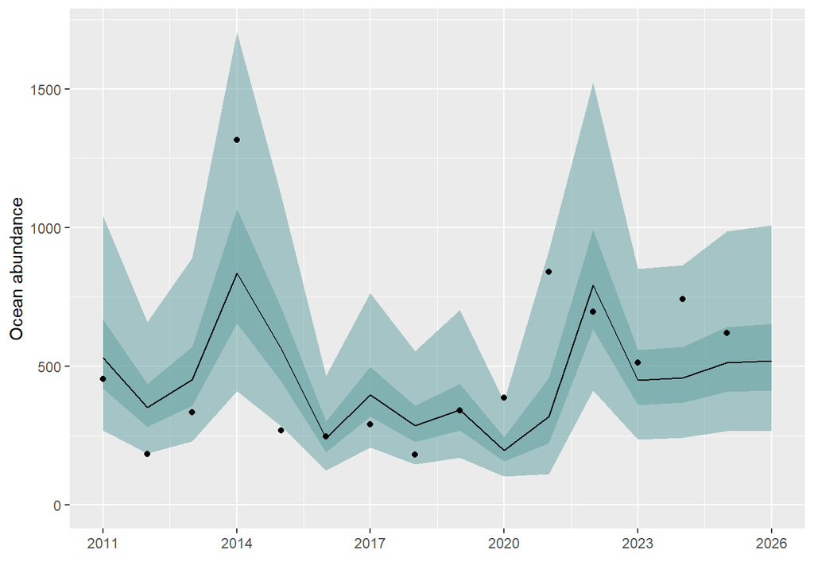

Figure 1. One-step-ahead predictions (black line) of total OPI coho abundance for the best model relative to observed abundance (black dots). Prediction intervals are shown as blue shading including 50% (dark), 95% (light)

```r
Figure1
```

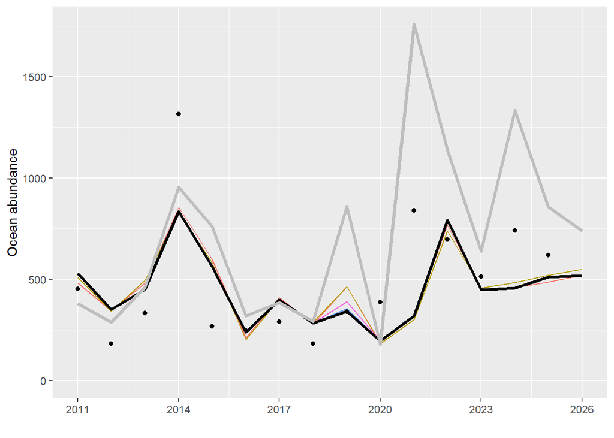

Figure 2. One-step-ahead predictions (lines) of total OPI coho abundance for the top model set relative to observed abundance (black dots).

```r
Figure2
```

Figure 3 shows the log transformed percent forecast error of the current and new model over time.

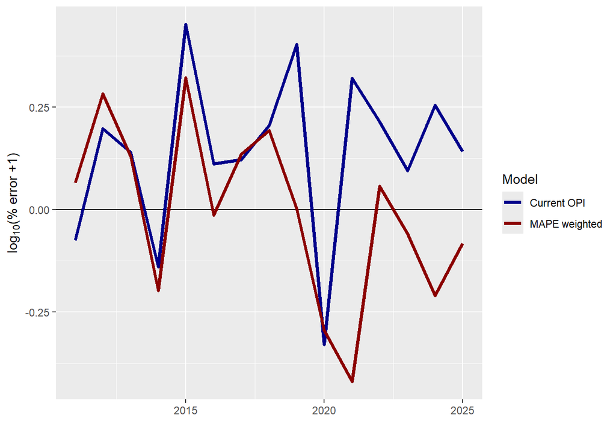

Figure 3. The log transformed percent forecast error of the current and new model over time.

```r
Figure3
```

Figure 4 shows time series of the z-scored covariate values.

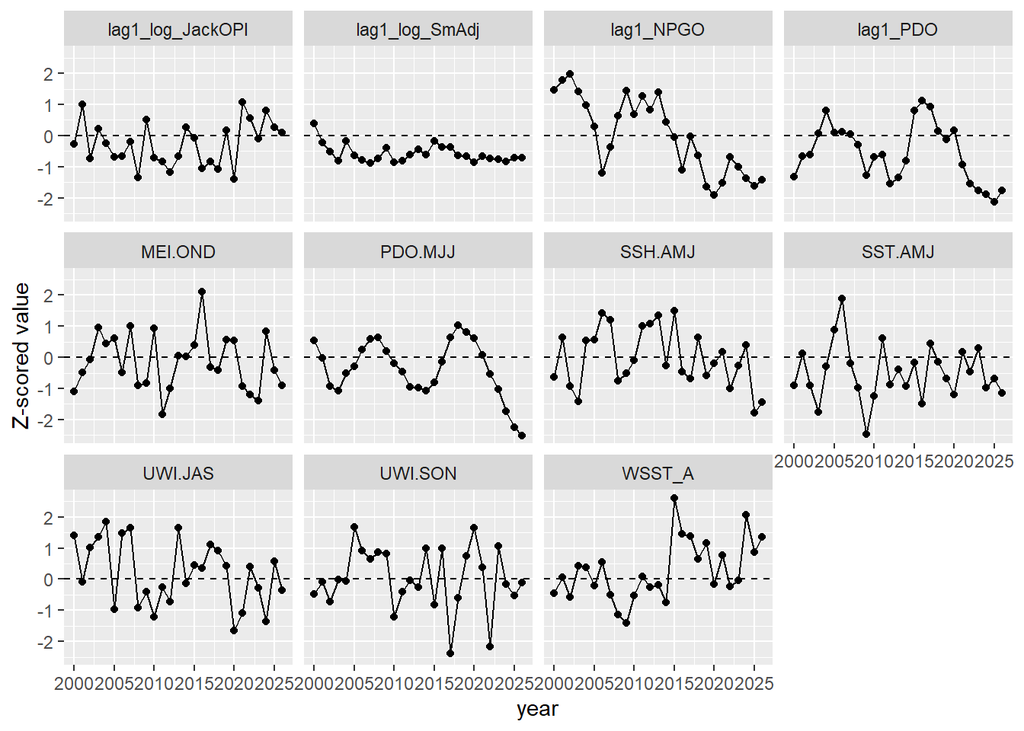

```r
integer_breaks <- function(n = 5, ...) {
  fxn <- function(x) {
    breaks <- floor(pretty(x, n, ...))
    names(breaks) <- attr(breaks, "labels")
    breaks
  }
  return(fxn)
}


dat %>% dplyr::select(all_of(covariates),year) %>% mutate(across(all_of(covariates),function(x)c(scale(x))),year=as.integer(year)) %>% pivot_longer(all_of(covariates),values_to = "Z-scored value") %>% filter(between(year,2000,2026)) %>% ggplot(aes(x=year,y=`Z-scored value`))+geom_point()+geom_line() + facet_wrap(~name)+geom_hline(yintercept = 0,lty=2)+scale_x_continuous(breaks=integer_breaks(),guide = guide_axis(check.overlap = TRUE))
```

## Appendix

Appendix 1 shows the raw data and covariates used in modeling.

```r
dat%>%
  dplyr::select(-period,-`...1`)%>%
  kbl(caption ="Appendix 1. data used for forecasting OPI Coho",digits =2)%>%
  kableExtra::kable_classic(full_width = F, html_font = "Cambria")
```

Appendix 1. data used for forecasting OPI Coho

| year | species | abundance | lag1_log_JackOPI | lag1_log_SmAdj | lag1_NPGO | lag1_PDO | WSST_A | PDO.MJJ | MEI.OND | UWI.JAS | SST.AMJ | SSH.AMJ | UWI.SON |
| --- | --- | --- | --- | --- | --- | --- | --- | --- | --- | --- | --- | --- | --- |
| 1970 | Coho | 2765.10 | 5.09 | 0.00 | -0.39 | 0.00 | 0.16 | -0.40 | 0.36 | 34.70 | 11.97 | -41.57 | -34.01 |
| 1971 | Coho | 3365.00 | 5.17 | 0.00 | 0.06 | -0.12 | -0.85 | -0.47 | -1.31 | 41.41 | 10.88 | -156.00 | -31.81 |
| 1972 | Coho | 1924.80 | 4.60 | 0.00 | 0.38 | -0.97 | -1.19 | -0.51 | -1.59 | 28.96 | 11.69 | -74.57 | -16.05 |
| 1973 | Coho | 1817.00 | 4.46 | 0.26 | -0.66 | -0.76 | -1.11 | -0.88 | 1.45 | 33.79 | 11.85 | -67.33 | -8.15 |
| 1974 | Coho | 3071.10 | 4.92 | 0.49 | 0.13 | -0.65 | -0.81 | -1.13 | -1.80 | 41.15 | 12.24 | -159.93 | -19.50 |
| 1975 | Coho | 1652.80 | 4.28 | 0.28 | -0.01 | -0.07 | -0.25 | -1.09 | -1.37 | 33.20 | 10.94 | -80.10 | -8.79 |
| 1976 | Coho | 3885.30 | 5.13 | 0.34 | 0.80 | -0.94 | -0.68 | -0.98 | -2.10 | 38.46 | 10.83 | -156.53 | -38.99 |
| 1977 | Coho | 987.50 | 3.98 | 0.03 | 1.86 | 0.01 | 0.47 | -0.68 | 0.50 | 22.62 | 10.69 | -117.93 | -7.94 |
| 1978 | Coho | 1824.10 | 4.62 | 0.00 | 1.25 | 0.33 | -0.16 | -0.41 | 0.75 | 30.15 | 11.20 | -141.50 | -34.77 |
| 1979 | Coho | 1476.70 | 4.26 | 0.64 | 0.50 | 0.38 | -0.60 | -0.31 | -0.14 | 16.88 | 11.58 | -91.97 | -5.59 |
| 1980 | Coho | 1224.00 | 4.04 | 0.91 | -0.74 | 0.44 | 0.60 | 0.14 | 0.38 | 24.02 | 11.22 | -96.27 | -58.73 |
| 1981 | Coho | 1064.50 | 3.87 | 0.74 | -0.75 | 0.56 | 0.10 | 0.35 | -0.03 | 48.08 | 12.06 | -68.30 | -42.72 |
| 1982 | Coho | 1266.80 | 3.64 | 0.72 | -0.22 | 0.99 | -0.18 | 0.68 | -0.22 | 28.80 | 12.15 | -85.03 | -54.10 |
| 1983 | Coho | NA | 4.25 | 0.75 | -0.69 | 0.09 | 0.02 | 0.60 | 1.95 | 28.85 | 10.98 | -71.63 | -42.97 |
| 1984 | Coho | 691.30 | 3.73 | 0.69 | -0.09 | 1.23 | 0.17 | 1.01 | -0.50 | 26.44 | 12.14 | -7.20 | -46.62 |
| 1985 | Coho | 717.50 | 3.59 | 1.04 | 0.62 | 0.71 | -0.32 | 1.01 | -0.38 | 38.12 | 11.43 | -64.80 | -52.44 |
| 1986 | Coho | 2412.00 | 4.37 | 1.78 | -0.39 | 0.32 | -1.17 | 0.72 | -0.07 | 36.91 | 10.95 | -81.23 | -12.17 |
| 1987 | Coho | 779.40 | 3.99 | 1.05 | -0.73 | 1.20 | -0.13 | 1.05 | 0.60 | 38.46 | 11.51 | -82.13 | -19.72 |
| 1988 | Coho | 1467.80 | 4.51 | 1.16 | 0.43 | 1.36 | 0.23 | 0.89 | 1.04 | 36.07 | 11.43 | -79.57 | -34.08 |
| 1989 | Coho | 1922.00 | 4.19 | 1.00 | 1.32 | 0.19 | -0.37 | 0.98 | -1.66 | 42.69 | 11.49 | -61.37 | -20.23 |
| 1990 | Coho | 713.60 | 3.97 | 1.09 | 0.61 | -0.29 | 0.07 | 0.97 | -0.42 | 35.53 | 11.62 | -63.17 | -4.82 |
| 1991 | Coho | 1816.50 | 4.26 | 0.97 | -0.20 | -0.48 | -0.67 | 0.71 | 0.03 | 42.94 | 12.01 | -61.13 | -12.08 |
| 1992 | Coho | 512.60 | 3.29 | 0.52 | -0.50 | -0.54 | -0.16 | -0.04 | 1.00 | 39.48 | 10.92 | -106.83 | -2.08 |
| 1993 | Coho | 223.30 | 3.43 | 0.52 | -1.09 | 0.89 | 0.03 | 0.16 | 0.64 | 36.75 | 12.72 | -25.97 | -24.99 |
| 1994 | Coho | 214.10 | 1.71 | 0.25 | -1.90 | 1.17 | 0.07 | 0.58 | 0.84 | 40.86 | 13.24 | 64.37 | 0.14 |
| 1995 | Coho | 139.40 | 2.47 | 0.26 | -1.21 | -0.18 | 0.03 | 0.58 | 1.26 | 39.04 | 11.45 | -58.40 | -13.29 |
| 1996 | Coho | 176.50 | 2.89 | 0.45 | -1.04 | 0.63 | 0.60 | 1.30 | -0.76 | 27.53 | 11.19 | -58.10 | -25.28 |
| 1997 | Coho | 195.60 | 3.02 | 0.33 | -0.97 | 0.81 | 0.01 | 1.24 | -0.36 | 56.80 | 11.44 | -40.13 | -4.70 |
| 1998 | Coho | 228.30 | 2.32 | 0.23 | -0.66 | 1.34 | 1.43 | 1.24 | 2.10 | 10.18 | 12.10 | -6.60 | -55.94 |
| 1999 | Coho | 372.50 | 3.37 | 0.35 | 0.54 | -0.12 | 0.42 | 1.20 | -1.31 | 49.68 | 11.38 | -32.57 | -43.26 |
| 2000 | Coho | 673.10 | 3.54 | 0.51 | 1.52 | -1.38 | -0.26 | 0.46 | -1.33 | 51.00 | 10.67 | -101.47 | -34.18 |
| 2001 | Coho | 1478.70 | 4.47 | 0.28 | 1.89 | -0.78 | 0.04 | -0.01 | -0.69 | 35.78 | 11.36 | -44.63 | -26.83 |
| 2002 | Coho | 689.50 | 3.20 | 0.16 | 2.08 | -0.74 | -0.33 | -0.74 | -0.26 | 47.08 | 10.68 | -113.73 | -38.19 |
| 2003 | Coho | 1009.90 | 3.90 | 0.05 | 1.47 | -0.13 | 0.26 | -0.87 | 0.84 | 50.48 | 10.11 | -135.43 | -25.90 |
| 2004 | Coho | 693.60 | 3.56 | 0.29 | 0.96 | 0.53 | 0.23 | -0.40 | 0.29 | 55.48 | 11.08 | -49.43 | -26.35 |
| 2005 | Coho | 454.20 | 3.24 | 0.11 | 0.21 | -0.11 | -0.11 | -0.22 | 0.48 | 26.99 | 11.86 | -47.77 | 4.34 |
| 2006 | Coho | 524.30 | 3.26 | 0.06 | -1.47 | -0.09 | 0.32 | 0.21 | -0.68 | 51.75 | 12.54 | -10.00 | -9.01 |
| 2007 | Coho | 545.30 | 3.59 | 0.02 | -0.55 | -0.15 | -0.29 | 0.49 | 0.88 | 53.57 | 11.15 | -19.90 | -14.10 |
| 2008 | Coho | 571.30 | 2.77 | 0.08 | 0.58 | -0.46 | -0.67 | 0.52 | -1.12 | 27.52 | 10.62 | -106.43 | -9.88 |
| 2009 | Coho | 1051.00 | 4.10 | 0.20 | 1.49 | -1.33 | -0.82 | 0.17 | -1.03 | 32.71 | 9.62 | -95.17 | -10.66 |
| 2010 | Coho | 546.50 | 3.23 | 0.03 | 0.64 | -0.82 | -0.31 | -0.15 | 0.80 | 24.32 | 10.45 | -77.07 | -47.08 |
| 2011 | Coho | 454.20 | 3.15 | 0.05 | 1.29 | -0.74 | 0.06 | -0.36 | -2.08 | 34.21 | 11.68 | -28.80 | -32.89 |
| 2012 | Coho | 183.10 | 2.89 | 0.13 | 0.79 | -1.57 | -0.14 | -0.77 | -1.22 | 29.33 | 10.70 | -25.67 | -26.30 |
| 2013 | Coho | 335.10 | 3.27 | 0.19 | 1.42 | -1.41 | -0.10 | -0.79 | -0.11 | 53.55 | 11.02 | -13.10 | -29.90 |
| 2014 | Coho | 1316.50 | 3.94 | 0.13 | 0.36 | -0.93 | -0.43 | -0.86 | -0.14 | 35.30 | 10.66 | -84.47 | -7.81 |
| 2015 | Coho | 268.90 | 3.68 | 0.29 | -0.20 | 0.53 | 1.54 | -0.65 | 0.24 | 41.26 | 11.17 | -7.07 | -40.11 |
| 2016 | Coho | 247.70 | 2.98 | 0.21 | -1.38 | 0.81 | 0.87 | -0.10 | 2.04 | 40.41 | 10.28 | -93.27 | -7.85 |
| 2017 | Coho | 291.80 | 3.13 | 0.22 | -0.16 | 0.63 | 0.81 | 0.54 | -0.50 | 47.98 | 11.58 | -103.60 | -68.23 |
| 2018 | Coho | 182.80 | 2.96 | 0.11 | -0.86 | -0.06 | 0.38 | 0.84 | -0.60 | 46.09 | 11.19 | -44.70 | -36.18 |
| 2019 | Coho | 340.70 | 3.86 | 0.11 | -1.96 | -0.30 | 0.69 | 0.67 | 0.42 | 41.06 | 10.82 | -99.37 | -12.37 |
| 2020 | Coho | 387.70 | 2.72 | 0.03 | -2.28 | -0.04 | -0.09 | 0.52 | 0.39 | 20.07 | 10.47 | -81.17 | 4.07 |
| 2021 | Coho | 841.30 | 4.52 | 0.10 | -1.84 | -1.04 | 0.46 | 0.07 | -1.15 | 25.56 | 11.40 | -65.40 | -18.89 |
| 2022 | Coho | 695.60 | 4.15 | 0.08 | -0.91 | -1.58 | -0.13 | -0.42 | -1.43 | 40.84 | 10.97 | -117.43 | -64.07 |
| 2023 | Coho | 514.20 | 3.66 | 0.07 | -1.26 | -1.78 | -0.02 | -0.82 | -1.62 | 33.83 | 11.47 | -84.37 | -6.61 |
| 2024 | Coho | 742.30 | 4.32 | 0.04 | -1.68 | -1.88 | 1.22 | -1.40 | 0.70 | 22.84 | 10.62 | -55.53 | -28.15 |
| 2025 | Coho | 619.34 | 3.93 | 0.09 | -1.94 | -2.11 | 0.51 | -1.81 | -0.60 | 42.62 | 10.82 | -151.60 | -34.91 |
| 2026 | Coho | NA | 3.80 | 0.09 | -1.74 | -1.78 | 0.81 | -2.03 | -1.12 | 33.09 | 10.51 | -136.87 | -27.34 |

OPI data and covariate notes: 1) Jack OPI = Total Jack CR and Jack OC. 2) Jack CR = Columbia River jack returns corrected for small adults. 3) Jack OC = Oregon coastal and California hatchery jack returns corrected for small adults. 4) Total OPI = Columbia River (Sm D + Sm CR), Oregon coastal and Klamath Basin. 5) Sm CR = Columbia River smolt releases from the previous year expected to return as adults in the year listed. 6) Sm D = Columbia River delayed smolt releases from the previous year expected to return as adults in the year listed 7) SmAdj = JackCR*(Sm D/Sm CR) (this is a covariate used in the past OPI forecast)

OCN covariates 1) Multivariate ENSO Index (Oct-Dec; t-1) 2) Spring Transition (Julian date; t-1) 3) Upwelling (July-Sept; t-1) 4) Upwelling (Sep-Nov; t-1) 5) Sea Surface Temperature (Jan; t) 6) Sea Surface Height (April-June; t-1) 7Z)PDO (mean May-July; averaged over the 4-years prior to the return year)

Ancillary Covariates 1) [Pacific Decadal Oscillation](https://www.ncei.noaa.gov/access/monitoring/pdo/) 2) [North Pacific Gyre Oscillation](http://www.o3d.org/npgo/) 3) [NOAA Ocean Indicators](https://www.fisheries.noaa.gov/west-coast/science-data/ocean-ecosystem-indicators-pacific-salmon-marine-survival-northern) 4) [NOAA NOAA Extended Reconstructed SST version 5](https://psl.noaa.gov/data/gridded/data.noaa.ersst.v5.html) 5) [NOAA Oceanic Nino 3.4 Index (lag 1 Oct-December mean)](https://psl.noaa.gov/gcos_wgsp/Timeseries/Nino34/)